# Tableaux et Listes

Une **liste** est une structure de données qui contient une séquence de valeurs.

Syntaxe:

```
[<valeur_1>, <valeur_2>, ..., <valeur_n>]
```

- Les valeurs ne sont pas nécessairement de même type.
- Une liste est une séquence

## Généralités

### Organisation de la mémoire

- La mémoire peut être vue comme un long ruban avec des zones protégées
- Chaque case mémoire (un octet) dispose d'une adresse propre.
- Le stockage d'une valeur peut prendre plusieurs octets.
- Certaines valeurs peuvent être de type "adresse" (8 octets ?).  
  On les représente symboliquement par une flèche.

### Tableau en mémoire

- Usuellement un ensemble de cases **contigues** en mémoire de **même taille**.
- On fait de l'arithmétique avec la taille d'un objet pour trouver la position d'un élément: $$@T[i] = @T[0] + i * taille(element)$$
- Avantage: Accès direct (rapide) à un élément.
- Inconvénient: Pas idéal pour des mises à jour:
  - Ajout: décalage si pas à la fin
  - Insertion/ suppression: décalage/suppression.

### Liste simplement (ou doublement) chainée

- Chaque élément connait son successeur (et prédecesseur si doublement chainée).
- Dispersion des éléments en mémoire.
- Une valeur spéciale indique la fin (et le début) de liste.
- Avantage: idéal pour des mises à jour (ajout, insertion, suppression)
- Inconvénient: Accès séquentiel à un élément (très lent si longue liste)

**Tableau ou Liste**:

- On doit faire un compromis entre efficacité de l'accès et des mises à jour.
- Dépend des langages de programmation (Python vs C)

## Listes (= Tableaux) en Python

### Tests

```python
from tqdm.notebook import tqdm_notebook
import random
from time import time
n = 10**5
```

```python
L = []
tps_append = []
for _ in tqdm_notebook(range(n)):
    val = random.randint(0, 100)
    debut = time()
    L.append(val)
    fin = time()
    tps_append.append(fin - debut)
```

```python
L = []
tps_insert = []
for _ in tqdm_notebook(range(n)):
    pos = random.randint(0, len(L))  ## insertion aléatoire
    val = random.randint(0, 100)
    debut = time()
    L.insert(pos, val)
    fin = time()
    tps_insert.append(fin - debut)
```

```python
import matplotlib.pyplot as plt
%matplotlib notebook

x = list(range(n))

plt.plot(x, tps_insert, label = "insert")
plt.plot(x, tps_append, label = "append")
plt.legend()
plt.show()
```

[output not shown]

### Liste et mémoire en Python

Une liste étant un objet, même une liste vide doit occupé de la place:

```python
from sys import getsizeof as sof    ## Nombre d'octets en mémoire
sof([])
```

```
72
```

```python
# 8 octets par valeur de plus
sof([1]), sof([1, 2]), sof([1, 2, 3])
```

```
(80, 88, 96)
```

```python
# Et ce quel soit le type et ses valeurs
sof(["lepetitchat"]), sof(["le", "petit"]), sof(["le", "petit", "chat"])
```

```
(80, 88, 96)
```

```python
# Même en mélangeant les types
sof(["lepetitchat"]), sof(["le", ["petit"]]), sof(["le", ["petit"], ["chat", False]])
```

```
(80, 88, 96)
```

Python ne stocke donc pas directement les valeurs dans la liste mais des **références** vers les données:

- Liste = Tableau d'adresses vers les élements de la liste
- Le type des éléments de la liste n'est pas connue de la liste
- Cela optimise la place mémoire

La croissance de la taille d'une liste est gérée par la [règle](https://github.com/python/cpython/blob/master/Objects/listobject.c):

```
    new_allocated = newsize + newsize // 8 + 3 si newsize < 9 (+6 sinon)
    new_allocated ~ 1.125 * newsize
```

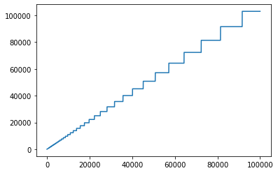

```python
import matplotlib.pyplot as plt
allocated = [0]
for size in range(1, 10**5):
    if size <= allocated[-1]:
        allocated.append(allocated[-1])
    else:
        newsize  = size + size // 8
        if size < 9:
            allocated.append(newsize+3)
        else:
            allocated.append(newsize+6)
plt.figure()
plt.plot(allocated)
plt.show()
```

Aparté: Principe identique pour les autres types

[output not shown]

### Ajout en tête

Quel est la meilleure solution pour le "prepend" (ajout en tête) ?

- Insertion systématique en position 0.
- Append pour chaque élement puis reverse à la fin.

### Conclusion

Classification (parcours, reallocation, cout)

- L[index]: rapide
- L.append: rapide (ev. réallocation)
- insert(index, objet) : lent
- remove(valeur): parcours jusqu'a trouve (lent) + décalage (lent) -> lent
- pop(index) ou del L[index]: décalage (lent)
- pop() (suppression dernier): rapide
- index(valeur): parcours jusqu'a trouve (lent)

## Compléments sur les listes

### Listes en compréhension

```
      L = [expression(x) for x in iterable if condition(x)]
```

où *iterable* est une séquence (liste, range, chaine, ...)

- La condition est optionnelle.
- Le résultat est une liste.
- En général sur une seule ligne.

Quelques usages:

- Construire une liste à partir de *range*.
- Créer une liste à partir d'une autre (filtrage)
- Se substituer à un *for* simple.
- Une liste de listes.

### Parcours simultané de plusieurs listes avec *zip*

```
     zip(*iterables)
```

où *iterables désigne 0, 1, 2, ... objets iterables (liste, chaine, dict, ...)

- le type retourné est *zip* qui est iterable ;)

```python
type(zip())
```

```
zip
```

```python
L1 = [2, 3, 5]
L2 = ['m', 'e', 't']

for (e1, e2) in zip(L1, L2):
    print(e1, '---', e2)
```

```
2 --- m
3 --- e
5 --- t
```

```python
for i, e1, e2 in enumerate(zip(L1, L2)):
    print(i,':', e1, '---', e2)
```

```
---------------------------------------------------------------------------
ValueError                                Traceback (most recent call last)
<ipython-input-4-3876be83ae22> in <module>
----> 1 for i, e1, e2 in enumerate(zip(L1, L2)):
      2     print(i,':', e1, '---', e2)

ValueError: not enough values to unpack (expected 3, got 2)
```

```python
for i, (e1, e2) in enumerate(zip(L1, L2)):
    print(i,':', e1, '---', e2)
```

```
0 : 2 --- m
1 : 3 --- e
2 : 5 --- t
```

On s'arrête sur la plus courte séquence:

```python
L1 = [2, 3, 5, 6, 1, 4]
L2 = ['m', 'e', 't']

for e1, e2 in zip(L1, L2):
    print(e1, '---', e2)
```

[output not shown]

Autre approche possible (sans zip):

```python
L1 = [2, 3, 5, 6, 1, 4]
L2 = ['m', 'e', 't']

for i in range(min(len(L1), len(L2))):
    print(L1[i], '---', L2[i])
```

[output not shown]

Cela devient difficile de faire mieux que:

```python
L1 = [2, 3, 5, 6, 1, 4]
L2 = ['m', 'e', 't', 'i', 'e', 'r']
L3 = [2**i for i in range(10)]
L4 = [True, True, False]*4

for e1, e2, e3, e4 in zip(L1, L2, L3, L4):
    print(e1, '---', e2, '---', e3, '---', e4)
```

```
2 --- m --- 1 --- True
3 --- e --- 2 --- True
5 --- t --- 4 --- False
6 --- i --- 8 --- True
1 --- e --- 16 --- True
4 --- r --- 32 --- False
```